# Inference, Etc

Author

Preye Indiamaowei

```r
library(tidyverse)
```

## Problem 1

The first two problems in this set refer to the ISLR2::Carseats set, which includes simulated sample data for 400 stores selling a particular brand of child carseat. We view this data as a simple random sample from a larger population.

Does this data provide evidence against the company’s claim that the average price of their own seats is $110? Follow all best practices from class, including hypotheses, a relevant visualization, and a conclusion in non-technical language.

```r
library(ISLR2)
glimpse(Carseats)
```

```
Rows: 400
Columns: 11
$ Sales       <dbl> 9.50, 11.22, 10.06, 7.40, 4.15, 10.81, 6.63, 11.85, 6.54, …
$ CompPrice   <dbl> 138, 111, 113, 117, 141, 124, 115, 136, 132, 132, 121, 117…
$ Income      <dbl> 73, 48, 35, 100, 64, 113, 105, 81, 110, 113, 78, 94, 35, 2…
$ Advertising <dbl> 11, 16, 10, 4, 3, 13, 0, 15, 0, 0, 9, 4, 2, 11, 11, 5, 0, …
$ Population  <dbl> 276, 260, 269, 466, 340, 501, 45, 425, 108, 131, 150, 503,…
$ Price       <dbl> 120, 83, 80, 97, 128, 72, 108, 120, 124, 124, 100, 94, 136…
$ ShelveLoc   <fct> Bad, Good, Medium, Medium, Bad, Bad, Medium, Good, Medium,…
$ Age         <dbl> 42, 65, 59, 55, 38, 78, 71, 67, 76, 76, 26, 50, 62, 53, 52…
$ Education   <dbl> 17, 10, 12, 14, 13, 16, 15, 10, 10, 17, 10, 13, 18, 18, 18…
$ Urban       <fct> Yes, Yes, Yes, Yes, Yes, No, Yes, Yes, No, No, No, Yes, Ye…
$ US          <fct> Yes, Yes, Yes, Yes, No, Yes, No, Yes, No, Yes, Yes, Yes, N…
```

```r
avg_price = mean(Carseats$Price, na.rm = TRUE)
```

The mean price according to this data is $115.80.

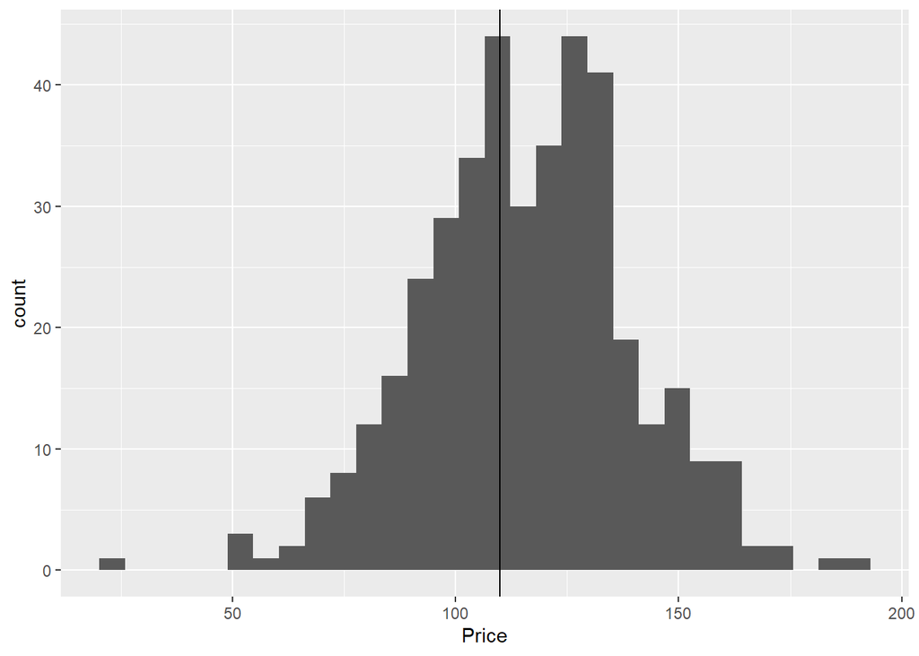

```r
Carseats %>%
  ggplot(aes(x = Price)) +
  geom_histogram() +
  geom_vline(xintercept = 110)
```

Null hypothesis: 110 ($H_0 : = 110 $)

Alternative hypothesis: mu isn’t 110 $(H_a : \mu \ne 110)$

```r
t.test(Carseats$Price,
mu = 110)
```

```
    One Sample t-test

data:  Carseats$Price
t = 4.8951, df = 399, p-value = 1.429e-06
alternative hypothesis: true mean is not equal to 110
95 percent confidence interval:
 113.4677 118.1223
sample estimates:
mean of x
  115.795
```

We can conclude the average price of this company’s car seats is not $110.

## Problem 2

Compute a level 90% confidence interval for the mean competitor price in the population from which this sample is drawn. What is the sample mean? What is the margin of error?

## Problem 3

Watch my video on contingency tables. Use these tools to create a table with counts of penguin species and home islands in the penguins set. Include marginal counts in your table.

```r
glimpse(penguins)
```

```
Rows: 344
Columns: 8
$ species     <fct> Adelie, Adelie, Adelie, Adelie, Adelie, Adelie, Adelie, Ad…
$ island      <fct> Torgersen, Torgersen, Torgersen, Torgersen, Torgersen, Tor…
$ bill_len    <dbl> 39.1, 39.5, 40.3, NA, 36.7, 39.3, 38.9, 39.2, 34.1, 42.0, …
$ bill_dep    <dbl> 18.7, 17.4, 18.0, NA, 19.3, 20.6, 17.8, 19.6, 18.1, 20.2, …
$ flipper_len <int> 181, 186, 195, NA, 193, 190, 181, 195, 193, 190, 186, 180,…
$ body_mass   <int> 3750, 3800, 3250, NA, 3450, 3650, 3625, 4675, 3475, 4250, …
$ sex         <fct> male, female, female, NA, female, male, female, male, NA, …
$ year        <int> 2007, 2007, 2007, 2007, 2007, 2007, 2007, 2007, 2007, 2007…
```

```r
# species, island
penguins_table <- table(penguins$species, penguins$island)

addmargins(penguins_table)
```

```
            Biscoe Dream Torgersen Sum
  Adelie        44    56        52 152
  Chinstrap      0    68         0  68
  Gentoo       124     0         0 124
  Sum          168   124        52 344
```

```r
penguins_table
```

```
            Biscoe Dream Torgersen
  Adelie        44    56        52
  Chinstrap      0    68         0
  Gentoo       124     0         0
```

## Problem 4

Push your solutions to this set to your GitHub page, including both the Quarto source and the rendered html. Use file names of the form, “math250_nov5_yourname.”

Provide a clickable link to the repository on your personal GitHub where these files can be found.